# Custom Feature Lags

Nick Redell, nickredell@hotmail.com

2019-08-17

## Purpose

[figure not shown]

The purpose of this vignette is to demonstrate how custom predictor or feature lags can be created for forecast model inputs in `forecastML` with the `forecastML::create_lagged_df()` function. The rationale behind creating custom feature lags is to improve model accuracy by removing noisy or redundant features in high dimensional training data. Keeping only those feature lags that show high autocorrelation or cross-correlation with the modeled outcome–e.g., 3 and 12 months for monthly data–is a good place to start.

## Load packages and data

```r
library(forecastML)
library(DT)

data("data_seatbelts", package = "forecastML")
data <- data_seatbelts

data <- data[, c("DriversKilled", "kms", "PetrolPrice", "law")]
DT::datatable(head(data, 5))
```

|  | DriversKilled | kms | PetrolPrice | law |
| --- | --- | --- | --- | --- |
| 1 | 107 | 9059 | 0.102971811805368 | 0 |
| 2 | 97 | 7685 | 0.102362995884646 | 0 |
| 3 | 102 | 9963 | 0.102062490635914 | 0 |
| 4 | 87 | 10955 | 0.100873300511862 | 0 |
| 5 | 119 | 11823 | 0.101019672891934 | 0 |

## Create a date column

- Dates are optional for forecasting with non-grouped data, but we’ll add a date column here to illustrate the functionality.
- The data set does not come with a date column, but the data was collected monthly from 1969 through 1984. This actually works out nicely because dates are passed in a separate argument, `dates`, in `forecastML::create_lagged_df()`.

```r
ts_date_interval <- "1 month"

dates <- seq(as.Date("1969-01-01"), as.Date("1984-12-01"), by = ts_date_interval)
```

## Custom feature lags

- We’ll use custom lags for each of our 4 modeled features using the `lookback_control` argument in `forecastML::create_lagged_df()`.
  - Column 1: 3 and 12 months in the past.
  - Column 2: 1 through 3 months in the past.
  - Column 3: 1 through 12 months in the past.
  - Column 4: 12 months in the past.
- Although it’s not required, our feature lags will be common across forecast models–3 models that forecast (1) 1 month out, (2) 1:6 months out, and (3) 1:12 months out. As we’ll see below, feature lags that don’t support direct forecasting to the given horizon are silently dropped from the lagged data.frames.

```r
horizons <- c(1, 6, 12)  # forecasting 1, 1:6, and 1:12 months into the future.

# A list of length 3, one slot for each modeled forecast horizon.
lookback_control <- vector("list", length(horizons))
lookback_control <- lapply(lookback_control, function(x) {
  list(
    c(3, 12),  # column 1: DriversKilled
    1:3,       # column 2: kms
    1:12,      # column 3: PetrolPrice
    12         # column 4: law
    )
  })

data_train <- forecastML::create_lagged_df(data, type = "train", outcome_cols = 1,
                                           lookback_control = lookback_control,
                                           horizons = horizons, dates = dates,
                                           frequency = ts_date_interval)
```

- Below is a series of feature-level plots of the resulting lagged data.frame features for each forecast horizon in data_train.
- Notice how the 1:3 month lags for `kms` were dropped from the 6- and 12-month-out forecast models because these lags don’t support direct forecasting at these time horizons.

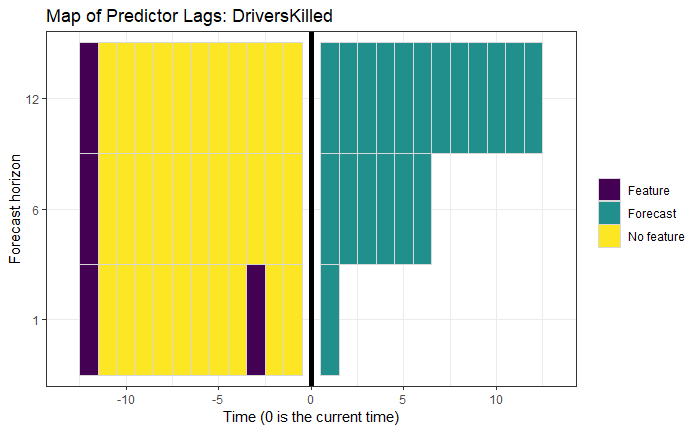

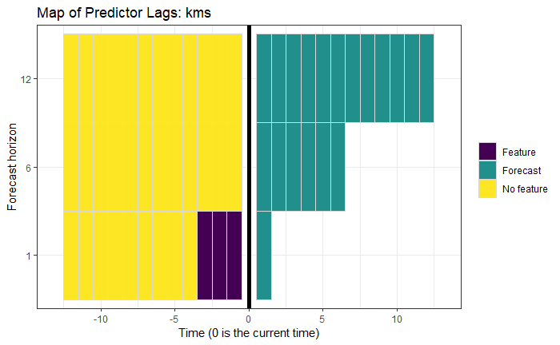

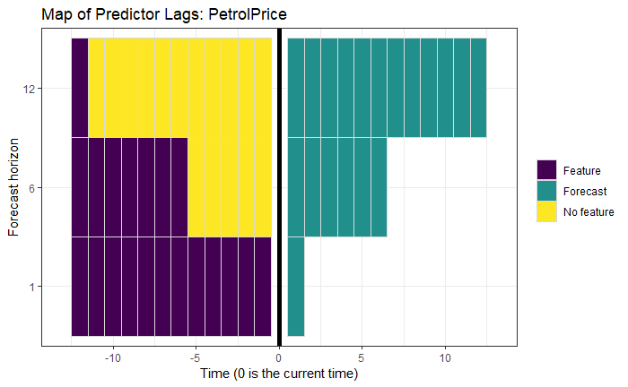

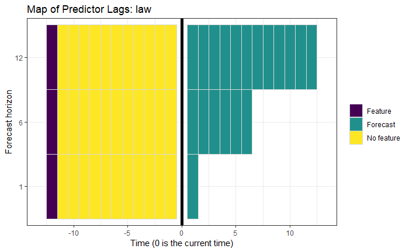

```r
plot(data_train)
```

## Removing features

- Now let’s say that a lag of 12 months for `PetrolPrice` is a poor predictor for our long-term, 12-month-out forecast model. We can remove it by assigning a `NULL` value in the appropriate slot in our `lookback_control` argument.
- Notice that the `NULL` has to be placed in a `list()` to avoid removing the list slot altogether. This will likely be deprecated in future releases in favor of `NA`.

```r
horizons <- c(1, 6, 12)  # forecasting 1, 1:6, and 1:12 months into the future.

# A list of length 3, one slot for each modeled forecast horizon.
lookback_control <- vector("list", length(horizons))
lookback_control <- lapply(lookback_control, function(x) {

  lapply(1:4, function(x) {1:12})  # 12 feature lags for each of our 4 modeled features.
  })

# Find the column index of the feature that we're removing.
remove_col <- which(grepl("PetrolPrice", names(data)))

# Remove the feature from the 12-month-out lagged data.frame.
lookback_control[[which(horizons == 12)]][remove_col] <- list(NULL)

data_train <- forecastML::create_lagged_df(data, type = "train", outcome_cols = 1,
                                           lookback_control = lookback_control,
                                           horizons = horizons, dates = dates,
                                           frequency = ts_date_interval)
```

- Inspecting the plot confirms that the 12-month-lagged feature for `PetrolPrice` is not a feature in our 12-month-out forecast model training data set.

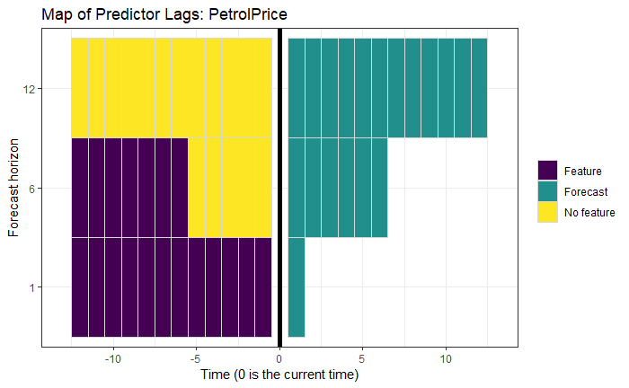

```r
plot(data_train)[[remove_col]]  # we're selecting 1 of our 4 feature-level plots.
```

- Inspecting the modeling data.frame confirms that the 12-month-lagged feature for `PetrolPrice` is not a feature in our 12-month-out forecast model training data set.

```r
DT::datatable(head(data_train[[which(horizons == 12)]]))
```

|  | DriversKilled | DriversKilled_lag_12 | kms_lag_12 | law_lag_12 |
| --- | --- | --- | --- | --- |
| 13 | 125 | 107 | 9059 | 0 |
| 14 | 134 | 97 | 7685 | 0 |
| 15 | 110 | 102 | 9963 | 0 |
| 16 | 102 | 87 | 10955 | 0 |
| 17 | 103 | 119 | 11823 | 0 |
| 18 | 111 | 106 | 12391 | 0 |